# Life Expectancy in Continents

Riccardo Santarossa

2026-11-09

In questo scenario, la Life Expectancy di un paese del mondo è calcolata come la *media* delle lunghezze delle vite degli abitanti di quel continente: per rendere coerente il calcolo anche a livello di continente, non basta fare la “media delle medie”, in quanto andremmo a trattare allo stesso modo paesi con un numero di abitanti molto diverso.

L’idea è quindi quella di utilizzare gli abitanti del paese e del continente come **pesi** di una media ponderata. Per ogni paese di un dato continente si eseguirà quindi prima la moltiplicazione delle life expectancies di ognuno per il numero degli abitanti e poi si dividerà il tutto per il numero totale di abitanti del continente.

$$Life Expectancy_{continente} = \dfrac{\sum_{paesi \in continente}^{}
(LifeExpectancy_{paese} *
popolazione_{paese})}{popolazione_{continente}}$$

Ciascuno di questi calcoli verrà poi ripetuto per ogni intervallo temporale, per poter poi visualizzare graficamente la variazione dell’aspettativa di vita per ogni continente e successivamente per tutto il mondo.

```r
library(ggplot2)
library(tidyverse)
library(gapminder)
library(purrr)
```

```r
#funzione che calcola l'aspettativa di vita di un continente
lifeExpectContinent = function(continente, anno){
  gapminder |>
    filter(continent == continente, year == anno) |>
    summarise(lifeExpWeighted = weighted.mean(lifeExp, pop)) |>
    pull(lifeExpWeighted)
}

#mappo la funzione per ogni coppia (continente, anno)
years = unique(gapminder$year)
continents = unique(gapminder$continent)

#map con pmap per gestire la coppia (continente, anno) in quanto ci sono più anni che continenti
#il normale map2 richiederebbe che le due variabili siano della stessa lunghezza
continentsLifeExp = expand.grid(continente = continents, anno = years)
continentsLifeExp = continentsLifeExp |>
  mutate(weightedLifeExp = pmap_dbl(list(continente, anno), lifeExpectContinent)) |>
  left_join(
    gapminder |>
      group_by(continent, year) |>
      summarise(totalPopulation = sum(pop), .groups = "drop"),
    by = c("continente" = "continent", "anno" = "year"))

continentsLifeExp |> head(15)
```

```
##    continente anno weightedLifeExp totalPopulation
## 1        Asia 1952        42.94114      1395357351
## 2      Europe 1952        64.90540       418120846
## 3      Africa 1952        38.79973       237640501
## 4    Americas 1952        60.23599       345152446
## 5     Oceania 1952        69.17040        10686006
## 6        Asia 1957        47.28835      1562780599
## 7      Europe 1957        66.89364       437890351
## 8      Africa 1957        40.94031       264837738
## 9    Americas 1957        62.01806       386953916
## 10    Oceania 1957        70.31693        11941976
## 11       Asia 1962        46.57369      1696357182
## 12     Europe 1962        68.45957       460355155
## 13     Africa 1962        43.09925       296516865
## 14   Americas 1962        63.43706       433270254
## 15    Oceania 1962        70.98808        13283518
```

Una volta calcolata la LifeExpectancy *pesata* la si può rappresentare in un grafico a linea per comprenderne l’andamento nel tempo per ciascuno dei 5 continenti

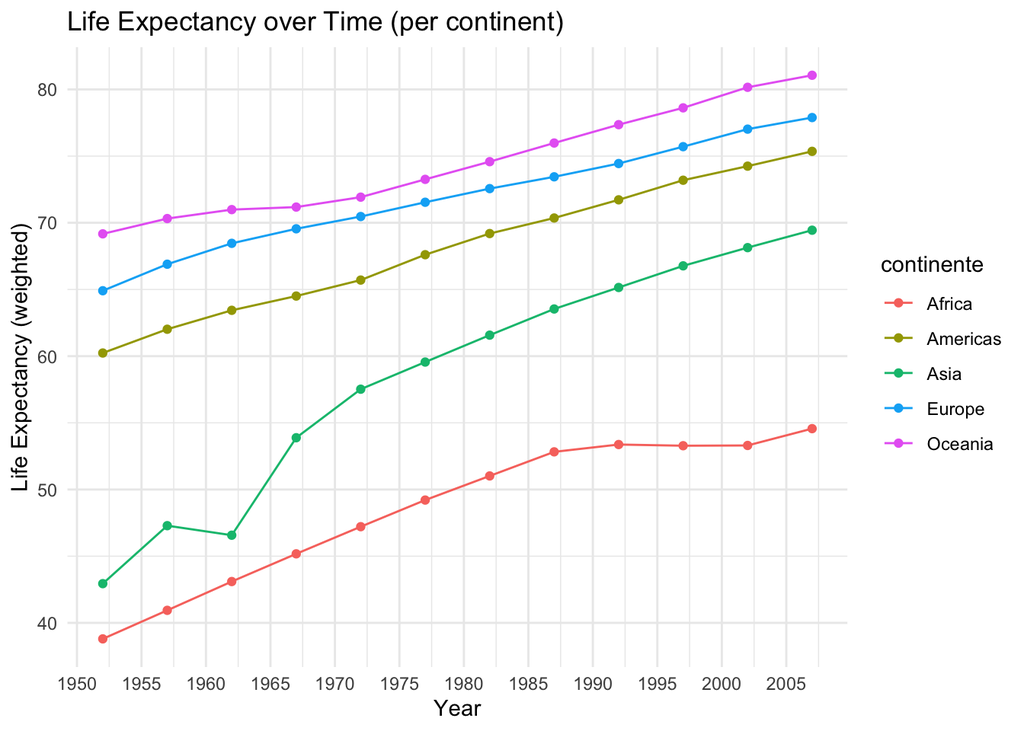

```r
#plot dell'aspettativa di vita dei continenti nel tempo
ggplot(continentsLifeExp, aes(x = anno, y = weightedLifeExp, color = continente)) +
  geom_point() +
  geom_line() +
  scale_x_continuous(breaks = seq(1950, 2010, by = 5)) +
  labs(title = "Life Expectancy over Time (per continent)", x = "Year", y = "Life Expectancy (weighted)") +
  theme_minimal()
```

Per calcolare invece la popolazione del mondo, applico la stessa filosofia utilizzata per i continenti, sfruttando però come popolazione totale quella ottenuta sommando la popolazione dei continenti in ogni anno (popolazione mondiale di quell’anno).

La funzione utilizzata sarà la stessa, ovvero la *weighted mean*

```r
#funzione che calcola la weighted life expectancy del mondo dato l'anno
worldLifeExp = function(annoTarget){
  continentsLifeExp |>
    filter(anno == annoTarget) |>
    summarise(worldLifeExp = weighted.mean(weightedLifeExp, totalPopulation)) |>
    pull(worldLifeExp)
}

#applico la funzione agli anni
lifeExpectWorld = data.frame(continente = "world", anni = years)
lifeExpectWorld = lifeExpectWorld |>
  mutate(worldLifeExpectancy = map_dbl(anni, worldLifeExp))

lifeExpectWorld
```

```
##    continente anni worldLifeExpectancy
## 1       world 1952            48.94424
## 2       world 1957            52.12189
## 3       world 1962            52.32438
## 4       world 1967            56.98431
## 5       world 1972            59.51478
## 6       world 1977            61.23726
## 7       world 1982            62.88176
## 8       world 1987            64.41635
## 9       world 1992            65.64590
## 10      world 1997            66.84934
## 11      world 2002            67.83904
## 12      world 2007            68.91909
```

Concludo utilizzando lo stesso grafico usato in precedenza, ma sulla base del nuovo DataFrame riguardante tutto il mondo

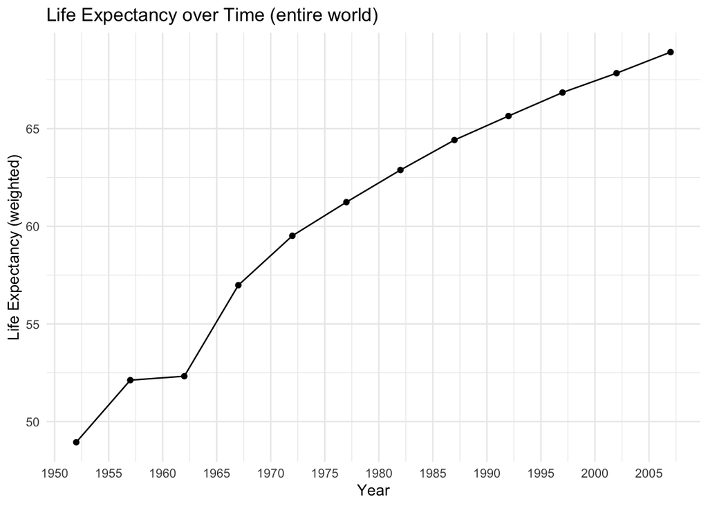

```r
#plot dell'aspettativa di vita mondiale
ggplot(lifeExpectWorld, aes(x = anni, y = worldLifeExpectancy)) +
  geom_point() +
  geom_line() +
  scale_x_continuous(breaks = seq(1950, 2010, by = 5)) +
  labs(title = "Life Expectancy over Time (entire world)", x = "Year", y = "Life Expectancy (weighted)") +
  theme_minimal()
```